# Diamond Assignment

Yousuf Ahmed Nahian

We want to study the `diamonds` dataset.

```r
library(ggplot2)
library(dplyr)
```

#### 1. Display the first few rows of the dataset.

```r
head(diamonds)
```

```
## # A tibble: 6 × 10
##   carat cut       color clarity depth table price     x     y     z
##   <dbl> <ord>     <ord> <ord>   <dbl> <dbl> <int> <dbl> <dbl> <dbl>
## 1  0.23 Ideal     E     SI2      61.5    55   326  3.95  3.98  2.43
## 2  0.21 Premium   E     SI1      59.8    61   326  3.89  3.84  2.31
## 3  0.23 Good      E     VS1      56.9    65   327  4.05  4.07  2.31
## 4  0.29 Premium   I     VS2      62.4    58   334  4.2   4.23  2.63
## 5  0.31 Good      J     SI2      63.3    58   335  4.34  4.35  2.75
## 6  0.24 Very Good J     VVS2     62.8    57   336  3.94  3.96  2.48
```

#### 2. The `cut` variable

```r
levels(diamonds$cut)
```

```
## [1] "Fair"      "Good"      "Very Good" "Premium"   "Ideal"
```

```r
table(diamonds$cut)
```

```
##
##      Fair      Good Very Good   Premium     Ideal
##      1610      4906     12082     13791     21551
```

2.1 Determine the type of the variable `cut` using `class()`.

```r
class(diamonds$cut)
```

```
## [1] "ordered" "factor"
```

2.2 What happens if you use `typeof()` instead? Do you have an idea why?

```r
typeof(diamonds$cut)
```

```
## [1] "integer"
```

class() = What kind of data is this for analysis? typeof() = How is it stored in memory?

#### 3. In which package is the dataset diamonds contained in? How can you look it up?

Diamonds Dataset is contained at ggplot2 package. Using ´help(“diamonds”) we can look up which package it belongs to.

#### 4. Create a scatterplot to study the relationship between `carat` and `price`. Add a linear trendline. Is the relationship positive or negative?

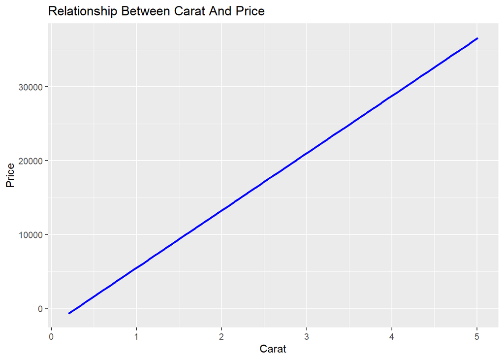

```r
library(ggplot2)
ggplot(diamonds, aes (x = carat, y = price)) + geom_smooth(method = "lm", col = "blue") + labs(title = "Relationship Between Carat And Price", x = "Carat", y = "Price")
```

From the graph we can see that as carat increases the price also increases. So, the relationship is Positive.

#### 5. Create a boxplot to visualize the distribution of price across different cuts. Are there patterns that seem surprising? Suggest possible explanations.

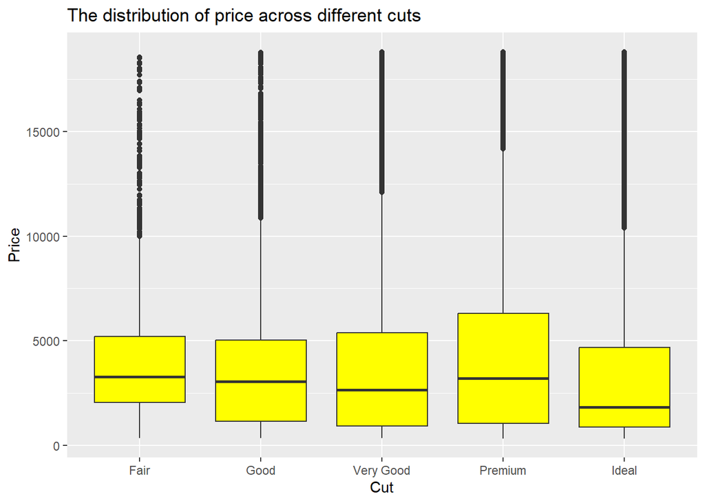

```r
library(ggplot2)
ggplot(diamonds, aes(x = cut, y = price)) + geom_boxplot(fill = "yellow") + labs(title = "The distribution of price across different cuts", x = "Cut", y= "Price")
```

So patterns seems surprising. Possible Explanations -

1.Price Depends on multiple factors, not just on cut.

2.Some lower carat diamonds can be more expensive due to its carat, rarity or clarity.

#### 6. Create scatterplots to investigate how the relationship between carat and price differs depending on the cut of the diamond. Write ~3 sentences to describe similarities and differences you observe between cuts.

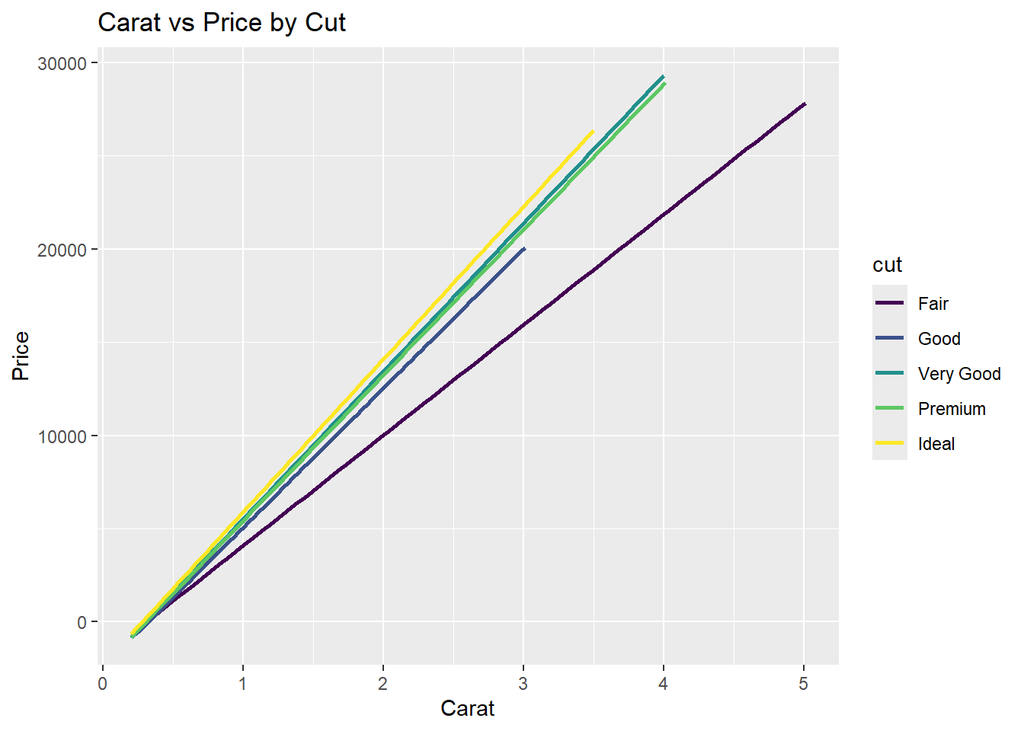

```r
ggplot(diamonds, aes(x = carat, y = price, color = cut)) +
  geom_smooth(method = "lm", se = FALSE) +
  labs(title = "Carat vs Price by Cut",
       x = "Carat",
       y = "Price")
```

All cuts show positive relationship.

#### True or False?

Are the following statements about the `diamonds` dataset true or false? Show code to justify your answer.

7. The diamonds dataset contains information on about 5400 diamonds.

False

```r
dim(diamonds)
```

```
## [1] 53940    10
```

8. Most diamonds in the dataset are priced below $5000.

True

```r
sum(diamonds$price < 5000)
```

```
## [1] 39213
```

9. The `geom_histogram()` function is used to show relationships between two numeric variables. (no code needed)

False